# Assignment8_SocialMedia

Akshita

2024-04-13

```r
social_media <- read.csv("C:/Users/HP/Downloads/Social_media_original.csv")
str(social_media)
```

```
## 'data.frame':    21 obs. of  25 variables:
##  $ Enter.5.character.id...not.your.net.id..or.your.name...It.should.be.same.throughout.the.survey.: chr  "masinl" "peace" "Patty" "Bunny" ...
##  $ Instagram                                                                                      : chr  "Yes" "Yes" "Yes" "Yes" ...
##  $ Hours.spent..HH.MM..Input.N.A.if.not.a.user                                                    : chr  "3.5" "7:44" "3:46" "5:23" ...
##  $ Linkedin                                                                                       : chr  "Yes" "Yes" "Yes" "Yes" ...
##  $ Hours.spent..HH.MM..Input.N.A.if.not.a.user.1                                                  : chr  "4" "5:12" "7:00" "5:19" ...
##  $ Snapchat                                                                                       : chr  "Yes" "Yes" "Yes" "Yes" ...
##  $ Hours.spent..HH.MM..Input.N.A.if.not.a.user.2                                                  : chr  "1" "3:41" "0:32" "1:18" ...
##  $ Twitter                                                                                        : chr  "Yes" "No" "No" "No" ...
##  $ Hours.spent..HH.MM..Input.N.A.if.not.a.user.3                                                  : chr  "5" "0:00" "N/A" "N/A" ...
##  $ Whatsapp..Wechat                                                                               : chr  "Yes" "Yes" "Yes" "Yes" ...
##  $ Hours.spent..HH.MM..Input.N.A.if.not.a.user.4                                                  : chr  "1" "4:11" "9:50" "5:18" ...
##  $ Youtube                                                                                        : chr  "Yes" "Yes" "Yes" "Yes" ...
##  $ Hours.spent..HH.MM..Input.N.A.if.not.a.user.5                                                  : chr  "2.5" "4:15" "1:51" "2:00" ...
##  $ OTT..Netflix..Hulu..Prime.video..                                                              : chr  "Yes" "No" "Yes" "Yes" ...
##  $ Hours.spent..HH.MM..Input.N.A.if.not.a.user.6                                                  : chr  "14.5" "0:00" "2:00" "2:00" ...
##  $ Reddit                                                                                         : chr  "Yes" "No" "No" "No" ...
##  $ Hours.spent..HH.MM..Input.N.A.if.not.a.user.7                                                  : chr  "2.5" "0:00" "N/A" "N.A" ...
##  $ Application.type.Social.media..OTT..Learning.                                                  : chr  "OTT" "Social Media" "Social Media" "Social Media" ...
##  $ How.many.job.interview.calls.received.in.this.week..                                           : chr  "N/A" "0" "0" "2" ...
##  $ How.much.networking.done.with.coffee.chats.                                                    : chr  "N/A" "1" "0" "0" ...
##  $ How.many.learning.done.in.terms.of.items.created.                                              : num  3 3 4 4 4 4 3 2 6 2 ...
##  $ Mood.Productivity                                                                              : chr  "Yes" "Yes" "Yes" "Yes" ...
##  $ Tired.waking.up.in.morning                                                                     : chr  "No" "No" "No" "No" ...
##  $ Trouble.falling.asleep                                                                         : chr  "No" "Yes" "No" "No" ...
##  $ How.you.felt.the.entire.week.                                                                  : int  3 3 4 4 3 5 4 4 3 2 ...
```

```r
social_media_cleaned <- social_media[,-1]

#changing column names
change_cols_index <- c(2,4,6,8,10,12,14,16,17,18,19,20,21,22,23,24)
change_cols_name <- c("Instagram_Time", "Linkedin_Time", "Snapchat_Time", "Twitter_Time", "Whatsapp_Time", "Youtube_Time", "OTT_Time", "Reddit_Time", "Application Type", "Interview_call_received", "Networking", "Learning", "Mood_Productivity", "Morning_tireness", "Sleep_trouble", "Weekly_Feelings")
colnames(social_media_cleaned)[change_cols_index] <- change_cols_name


# Convert "NA", "N/A", "n/a", "na", "N.A", "n.a" to 0
social_media_cleaned[social_media_cleaned == "NA" | social_media_cleaned == "N/A" | social_media_cleaned == "na" | social_media_cleaned == "n/a" | social_media_cleaned == "N.A" | social_media_cleaned == "n.a" | social_media_cleaned == "0" | social_media_cleaned == ""] <- NA
social_media_cleaned[is.na(social_media_cleaned)] <- 0

# Define a function to convert time strings to decimal hours
convert_to_decimal_hours <- function(time_string) {
# Check if NA values are present
if (any(is.na(time_string))) {
         return(rep(NA, length(time_string)))  # Return NA for NA values
     }

# Define a function to convert HH:MM format to decimal hours
     hhmm_to_decimal <- function(hhmm) {
         parts <- as.numeric(strsplit(hhmm, ":")[[1]])  # Split into hours and minutes
         hours <- parts[1]
         minutes <- ifelse(length(parts) > 1, parts[2], 0)  # Handle missing minutes
         total_hours <- hours + minutes / 60
         return(total_hours)
     }

# Convert time strings to decimal hours
decimal_hours <- sapply(time_string, function(x) {
         if (grepl("^\\d+:\\d+$", x)) {
             return(hhmm_to_decimal(x))  # Convert HH:MM format
         } else if (grepl("^\\d+\\.\\d+$", x)) {
             return(as.numeric(x))  # Convert decimal format
         } else if (grepl("^\\d+$", x)) {
             return(as.numeric(x))  # Convert whole numbers
         } else {
             return(NA)  # Return NA for other cases
         }
     })

     return(decimal_hours)
}

time_columns <- c("Instagram_Time", "Linkedin_Time", "Snapchat_Time", "Twitter_Time", "Whatsapp_Time", "Youtube_Time", "OTT_Time", "Reddit_Time")
# Apply the conversion function to all time columns
social_media_cleaned[time_columns] <- lapply(social_media_cleaned[time_columns], convert_to_decimal_hours)

# Verify the result
str(social_media_cleaned)
```

```
## 'data.frame':    21 obs. of  24 variables:
##  $ Instagram                        : chr  "Yes" "Yes" "Yes" "Yes" ...
##  $ Instagram_Time                   : num  3.5 7.73 3.77 5.38 0 ...
##  $ Linkedin                         : chr  "Yes" "Yes" "Yes" "Yes" ...
##  $ Linkedin_Time                    : num  4 5.2 7 5.317 0.583 ...
##  $ Snapchat                         : chr  "Yes" "Yes" "Yes" "Yes" ...
##  $ Snapchat_Time                    : num  1 3.683 0.533 1.3 0 ...
##  $ Twitter                          : chr  "Yes" "No" "No" "No" ...
##  $ Twitter_Time                     : num  5 0 0 0 0.667 ...
##  $ Whatsapp..Wechat                 : chr  "Yes" "Yes" "Yes" "Yes" ...
##  $ Whatsapp_Time                    : num  1 4.18 9.83 5.3 3 ...
##  $ Youtube                          : chr  "Yes" "Yes" "Yes" "Yes" ...
##  $ Youtube_Time                     : num  2.5 4.25 1.85 2 3.5 7 3 2 4 3 ...
##  $ OTT..Netflix..Hulu..Prime.video..: chr  "Yes" "No" "Yes" "Yes" ...
##  $ OTT_Time                         : num  14.5 0 2 2 2 3 0 3 3 0 ...
##  $ Reddit                           : chr  "Yes" "No" "No" "No" ...
##  $ Reddit_Time                      : num  2.5 0 0 0 1 0 0 0 0 0 ...
##  $ Application Type                 : chr  "OTT" "Social Media" "Social Media" "Social Media" ...
##  $ Interview_call_received          : chr  "0" "0" "0" "2" ...
##  $ Networking                       : chr  "0" "1" "0" "0" ...
##  $ Learning                         : num  3 3 4 4 4 4 3 2 6 2 ...
##  $ Mood_Productivity                : chr  "Yes" "Yes" "Yes" "Yes" ...
##  $ Morning_tireness                 : chr  "No" "No" "No" "No" ...
##  $ Sleep_trouble                    : chr  "No" "Yes" "No" "No" ...
##  $ Weekly_Feelings                  : int  3 3 4 4 3 5 4 4 3 2 ...
```

```r
#Treating NA in whatsapp column
mean_value <- mean(social_media_cleaned$Whatsapp_Time, na.rm = TRUE)
social_media_cleaned$Whatsapp_Time[is.na(social_media_cleaned$Whatsapp_Time)] <- mean_value

# Convert 'No' and 'Yes' to 0 and 1
social_media_cleaned$Mood_Productivity <- ifelse(social_media_cleaned$Mood_Productivity == "No", 0, 1)

social_media_cleaned$Morning_tireness <- ifelse(social_media_cleaned$Morning_tireness == "No", 0, 1)

social_media_cleaned$Sleep_trouble <- ifelse(social_media_cleaned$Sleep_trouble == "No", 0, 1)

# Select the relevant columns
time_columns <- social_media_cleaned[, grepl("_Time", colnames(social_media_cleaned))]
other_columns <- social_media_cleaned[c("Weekly_Feelings")]

# Combine the columns
combined_data <- cbind(time_columns, other_columns)
# Compute the correlation matrix
correlation_matrix <- cor(combined_data)
# Print the correlation matrix
print(correlation_matrix)
```

```
##                 Instagram_Time Linkedin_Time Snapchat_Time Twitter_Time
## Instagram_Time      1.00000000   0.312136719    0.75664722   -0.2081875
## Linkedin_Time       0.31213672   1.000000000    0.38172781   -0.1300779
## Snapchat_Time       0.75664722   0.381727806    1.00000000   -0.1669074
## Twitter_Time       -0.20818752  -0.130077891   -0.16690740    1.0000000
## Whatsapp_Time       0.57293521   0.262416318    0.40952048   -0.4874131
## Youtube_Time        0.28325552   0.452170173    0.24346648   -0.1882119
## OTT_Time            0.28995756   0.185481917    0.45625980    0.5570731
## Reddit_Time        -0.12784724  -0.007102435   -0.02822626    0.1648546
## Weekly_Feelings     0.03365761   0.415524861   -0.14819837   -0.1455712
##                 Whatsapp_Time Youtube_Time   OTT_Time  Reddit_Time
## Instagram_Time      0.5729352    0.2832555  0.2899576 -0.127847241
## Linkedin_Time       0.2624163    0.4521702  0.1854819 -0.007102435
## Snapchat_Time       0.4095205    0.2434665  0.4562598 -0.028226256
## Twitter_Time       -0.4874131   -0.1882119  0.5570731  0.164854559
## Whatsapp_Time       1.0000000    0.4178303  0.1515804 -0.126931653
## Youtube_Time        0.4178303    1.0000000  0.1605431  0.026216397
## OTT_Time            0.1515804    0.1605431  1.0000000  0.232735069
## Reddit_Time        -0.1269317    0.0262164  0.2327351  1.000000000
## Weekly_Feelings     0.2036196    0.1788234 -0.1088453 -0.155898691
##                 Weekly_Feelings
## Instagram_Time       0.03365761
## Linkedin_Time        0.41552486
## Snapchat_Time       -0.14819837
## Twitter_Time        -0.14557124
## Whatsapp_Time        0.20361959
## Youtube_Time         0.17882335
## OTT_Time            -0.10884527
## Reddit_Time         -0.15589869
## Weekly_Feelings      1.00000000
```

1. Model Development

```r
sm_model_fit <- lm(Weekly_Feelings ~ Linkedin_Time + Snapchat_Time + Twitter_Time + Whatsapp_Time + Youtube_Time + OTT_Time + Reddit_Time, data = combined_data)
#show the results
summary(sm_model_fit)
```

```
##
## Call:
## lm(formula = Weekly_Feelings ~ Linkedin_Time + Snapchat_Time +
##     Twitter_Time + Whatsapp_Time + Youtube_Time + OTT_Time +
##     Reddit_Time, data = combined_data)
##
## Residuals:
##     Min      1Q  Median      3Q     Max
## -1.0151 -0.2877 -0.1387  0.2644  1.2813
##
## Coefficients:
##                Estimate Std. Error t value Pr(>|t|)
## (Intercept)    2.918352   0.504595   5.784 6.35e-05 ***
## Linkedin_Time  0.164898   0.079324   2.079    0.058 .
## Snapchat_Time -0.190474   0.130462  -1.460    0.168
## Twitter_Time  -0.028311   0.246641  -0.115    0.910
## Whatsapp_Time  0.042920   0.061791   0.695    0.500
## Youtube_Time  -0.027071   0.115181  -0.235    0.818
## OTT_Time       0.007426   0.091461   0.081    0.937
## Reddit_Time   -0.062967   0.111153  -0.566    0.581
## ---
## Signif. codes:  0 '***' 0.001 '**' 0.01 '*' 0.05 '.' 0.1 ' ' 1
##
## Residual standard error: 0.7431 on 13 degrees of freedom
## Multiple R-squared:  0.3558, Adjusted R-squared:  0.008946
## F-statistic: 1.026 on 7 and 13 DF,  p-value: 0.4583
```

```r
#Summary has three sections. Section1: How well does the model fit the data (before Coefficients). Section2: Is the hypothesis supported? (until sifnif codes). Section3: How well does data fit the model (again).
# Useful Helper Functions
coefficients(sm_model_fit)
```

```
##   (Intercept) Linkedin_Time Snapchat_Time  Twitter_Time Whatsapp_Time
##   2.918352177   0.164897879  -0.190474368  -0.028310560   0.042920375
##  Youtube_Time      OTT_Time   Reddit_Time
##  -0.027071370   0.007425813  -0.062967158
```

The intercept coefficient is 2.918, indicating the estimated weekly feelings when the time spent on all social media platforms is zero. However, this interpretation might not be practically meaningful given that spending zero time on all platforms is unlikely.

Linkedin_Time: The coefficient for Linkedin_Time is 0.165. It suggests that for each unit increase in time spent on LinkedIn, weekly feelings increase by approximately 0.165 units, although the p-value is marginally above the conventional significance level of 0.05 (p = 0.058).

Snapchat_Time: The coefficient for Snapchat_Time is -0.190. It suggests that for each unit increase in time spent on Snapchat, weekly feelings decrease by approximately 0.190 units, though this effect is not statistically significant at the 0.05 level (p = 0.168).

Twitter_Time, Whatsapp_Time, Youtube_Time, OTT_Time, Reddit_Time: None of these coefficients are statistically significant, as their p-values are all greater than 0.05.

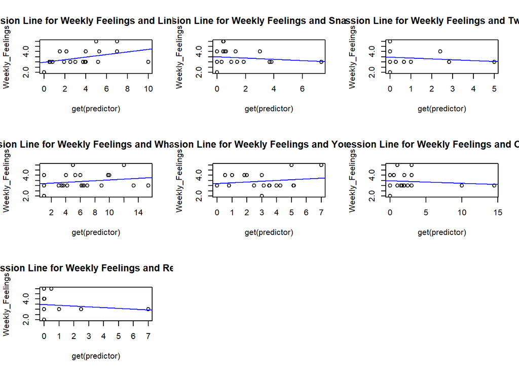

```r
# Plot scatterplots with regression lines for each predictor variable
par(mfrow = c(3, 3))  # Arrange plots in a 3x3 grid

# Loop through each predictor variable
predictor_vars <- c("Linkedin_Time", "Snapchat_Time", "Twitter_Time", "Whatsapp_Time", "Youtube_Time", "OTT_Time", "Reddit_Time")
for (predictor in predictor_vars) {
  plot(Weekly_Feelings ~ get(predictor), data = combined_data,
       main = paste("Regression Line for Weekly Feelings and", predictor))
  abline(lm(Weekly_Feelings ~ get(predictor), data = combined_data), col = "blue")
}

# Reset plotting parameters
par(mfrow = c(1, 1))
```

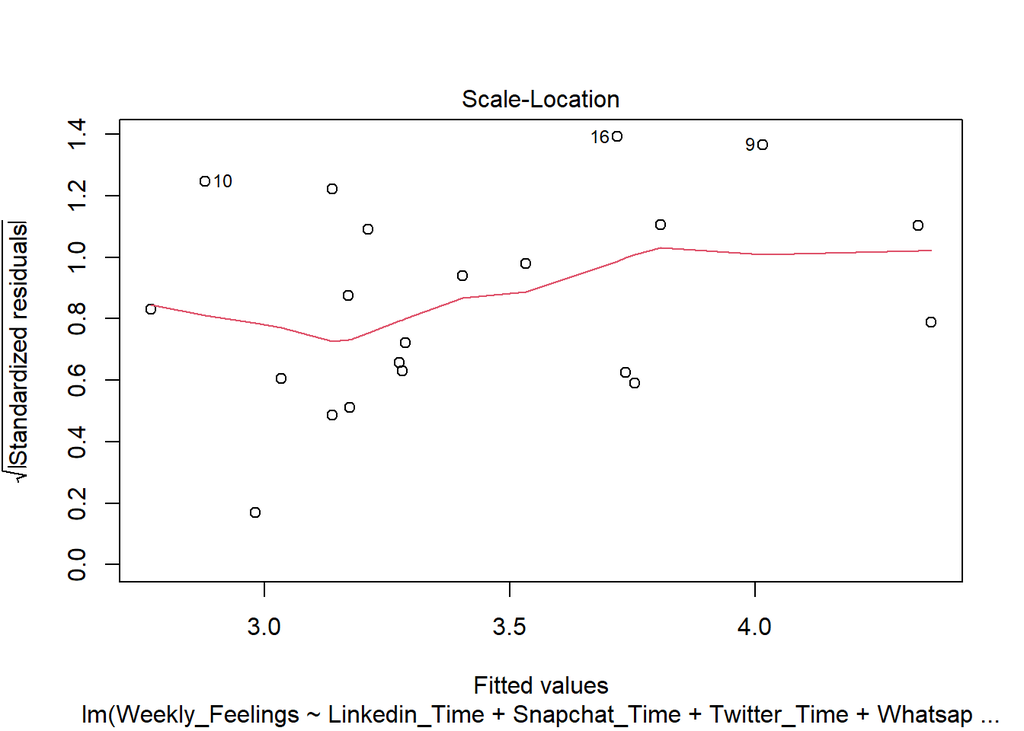

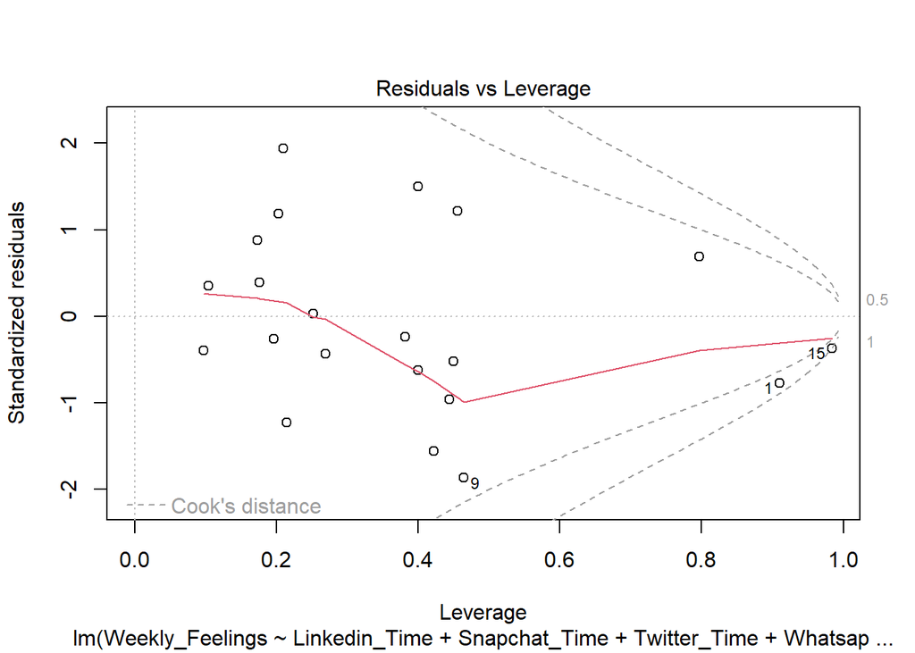

```r
# Diagnostic plots for the linear regression model
plot(sm_model_fit)
```

2. Model Acceptance

```r
# Assess the acceptance of the model
# Check R-squared and adjusted R-squared
r_squared <- summary(sm_model_fit)$r.squared
adj_r_squared <- summary(sm_model_fit)$adj.r.squared
cat("R-squared:", r_squared, "\n")
```

```
## R-squared: 0.3558148
```

```r
cat("Adjusted R-squared:", adj_r_squared, "\n")
```

```
## Adjusted R-squared: 0.008945826
```

```r
# Check the F-statistic and its p-value
f_statistic <- summary(sm_model_fit)$fstatistic
f_statistic_value <- f_statistic[1]
f_statistic_p_value <- pf(f_statistic_value, f_statistic[2], f_statistic[3], lower.tail = FALSE)
cat("F-statistic:", f_statistic_value, "\n")
```

```
## F-statistic: 1.02579
```

```r
cat("p-value:", f_statistic_p_value, "\n")
```

```
## p-value: 0.458319
```

The R-squared value is 0.3558148, indicating that approximately 35.58% of the variance in weekly feelings is explained by the predictor variables included in the model. The adjusted R-squared value is 0.008945826, which is very close to zero. This suggests that the model’s explanatory power is not significantly improved by the inclusion of the predictor variables.

The F-statistic is 1.02579, indicating how well the model fits the data. The associated p-value (0.458319) is greater than the conventional significance level of 0.05. A high p-value suggests that the model as a whole is not statistically significant.

The adjusted R-squared value being close to zero and the low F-statistic with a high p-value indicate that the model does not provide a good fit to the data.

The lack of significance in the F-test suggests that the predictor variables, as a group, do not significantly contribute to explaining the variance in weekly feelings.

Therefore, the model may not be suitable for acceptance as a reliable predictor of weekly feelings based on the time spent on social media platforms alone.

3. Residual Analysis

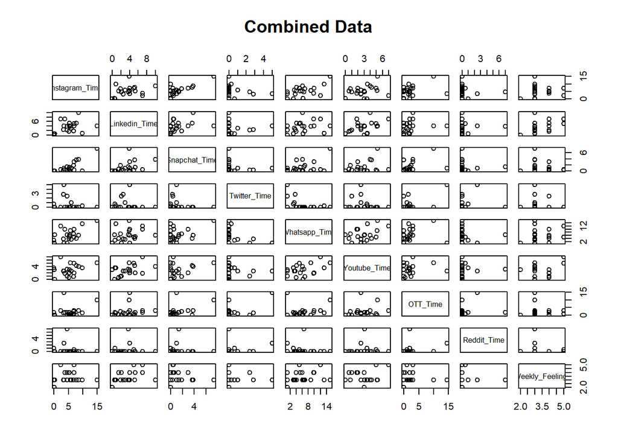

```r
# Plot pairs
pairs(combined_data, main = "Combined Data")
```

```r
confint(sm_model_fit,level=0.95)
```

```
##                     2.5 %     97.5 %
## (Intercept)    1.82824008 4.00846427
## Linkedin_Time -0.00647160 0.33626736
## Snapchat_Time -0.47232031 0.09137157
## Twitter_Time  -0.56114622 0.50452510
## Whatsapp_Time -0.09057008 0.17641083
## Youtube_Time  -0.27590497 0.22176223
## OTT_Time      -0.19016388 0.20501550
## Reddit_Time   -0.30309902 0.17716471
```

```r
fitted(sm_model_fit)
```

```
##        1        2        3        4        5        6        7        8
## 3.171415 3.138737 4.357871 3.735629 2.981565 4.331572 3.754252 3.403859
##        9       10       11       12       13       14       15       16
## 4.015131 2.880058 3.138202 3.287727 3.211709 3.280653 3.034502 3.718665
##       17       18       19       20       21
## 3.532556 3.173811 3.807491 2.769278 3.275316
```

```r
residuals(sm_model_fit)
```

```
##           1           2           3           4           5           6
## -0.17141487 -0.13873747 -0.35787095  0.26437057  0.01843530  0.66842836
##           7           8           9          10          11          12
##  0.24574817  0.59614096 -1.01513149 -0.88005844  0.86179818 -0.28772717
##          13          14          15          16          17          18
##  0.78829074 -0.28065289 -0.03450205  1.28133549 -0.53255595 -0.17381081
##          19          20          21
## -0.80749133  0.23072151 -0.27531586
```

```r
# Plot residuals vs. fitted values
plot(sm_model_fit, which = 1)
```

[output not shown]

```r
# Plot normal Q-Q plot of residuals
plot(sm_model_fit, which = 2)
```

[output not shown]

The curved points may indicate that the residuals or the data itself are not normally distributed.

Curved points may also suggest unequal variance (heteroscedasticity) in the residuals, where the spread of the residuals varies across different levels of the predictor variables.

In some cases, curved points may suggest nonlinearity in the relationship between the predictors and the response variable. This indicates that the linear regression model may not adequately capture the true relationship.

4. Prediction

```r
# Make predictions
predictions <- predict(sm_model_fit, newdata = combined_data)

# Print predictions
print(predictions)
```

```
##        1        2        3        4        5        6        7        8
## 3.171415 3.138737 4.357871 3.735629 2.981565 4.331572 3.754252 3.403859
##        9       10       11       12       13       14       15       16
## 4.015131 2.880058 3.138202 3.287727 3.211709 3.280653 3.034502 3.718665
##       17       18       19       20       21
## 3.532556 3.173811 3.807491 2.769278 3.275316
```

The model has generated predictions for weekly feelings for each observation in the dataset.

Each prediction represents the model’s estimate of the weekly feelings for a particular individual based on their time spent on various social media platforms.

These predictions can be used to gain insights into how the time spent on different social media platforms may influence individuals’ weekly feelings.

5. Model Accuracy

```r
# Calculate Mean Squared Error (MSE)
mse <- mean(sm_model_fit$residuals^2)

# Calculate Root Mean Squared Error (RMSE)
rmse <- sqrt(mse)

# Calculate Mean Absolute Error (MAE)
mae <- mean(abs(sm_model_fit$residuals))

# Print the accuracy metrics
cat("Mean Squared Error (MSE):", mse, "\n")
```

```
## Mean Squared Error (MSE): 0.3418126
```

```r
cat("Root Mean Squared Error (RMSE):", rmse, "\n")
```

```
## Root Mean Squared Error (RMSE): 0.5846474
```

```r
cat("Mean Absolute Error (MAE):", mae, "\n")
```

```
## Mean Absolute Error (MAE): 0.4719304
```

The calculated MSE, RMSE, and MAE values provide insights into the model’s predictive accuracy.

With MSE of 0.3418126, RMSE of 0.5846474, and MAE of 0.4719304, the model’s performance appears to be moderate.

These values suggest that, on average, the model’s predictions are off by approximately 0.58 units of weekly feelings when considering RMSE, and approximately 0.47 units when considering MAE.

```r
#Anova Table
anova(sm_model_fit)
```

```
## Analysis of Variance Table
##
## Response: Weekly_Feelings
##               Df Sum Sq Mean Sq F value  Pr(>F)
## Linkedin_Time  1 1.9239 1.92394  3.4844 0.08466 .
## Snapchat_Time  1 1.2279 1.22786  2.2237 0.15976
## Twitter_Time   1 0.2058 0.20578  0.3727 0.55207
## Whatsapp_Time  1 0.3833 0.38332  0.6942 0.41978
## Youtube_Time   1 0.0425 0.04250  0.0770 0.78581
## OTT_Time       1 0.0042 0.00421  0.0076 0.93176
## Reddit_Time    1 0.1772 0.17719  0.3209 0.58071
## Residuals     13 7.1781 0.55216
## ---
## Signif. codes:  0 '***' 0.001 '**' 0.01 '*' 0.05 '.' 0.1 ' ' 1
```

```r
vcov(sm_model_fit)
```

```
##               (Intercept) Linkedin_Time Snapchat_Time  Twitter_Time
## (Intercept)    0.25461652 -0.0104516422 -0.0117814616 -0.0780609625
## Linkedin_Time -0.01045164  0.0062923260 -0.0024414092  0.0005263211
## Snapchat_Time -0.01178146 -0.0024414092  0.0170203241  0.0143947146
## Twitter_Time  -0.07806096  0.0005263211  0.0143947146  0.0608318236
## Whatsapp_Time -0.01983325  0.0001709810  0.0003347872  0.0091728076
## Youtube_Time  -0.01574602 -0.0034868204  0.0011567505  0.0014338029
## OTT_Time       0.02074372 -0.0001202330 -0.0070006170 -0.0180012616
## Reddit_Time   -0.01235527  0.0001368041  0.0022840570  0.0045158247
##               Whatsapp_Time  Youtube_Time      OTT_Time   Reddit_Time
## (Intercept)   -0.0198332535 -0.0157460165  0.0207437151 -0.0123552721
## Linkedin_Time  0.0001709810 -0.0034868204 -0.0001202330  0.0001368041
## Snapchat_Time  0.0003347872  0.0011567505 -0.0070006170  0.0022840570
## Twitter_Time   0.0091728076  0.0014338029 -0.0180012616  0.0045158247
## Whatsapp_Time  0.0038180769 -0.0017629217 -0.0026342239  0.0014148683
## Youtube_Time  -0.0017629217  0.0132666816 -0.0007784608 -0.0007330024
## OTT_Time      -0.0026342239 -0.0007784608  0.0083651325 -0.0029561590
## Reddit_Time    0.0014148683 -0.0007330024 -0.0029561590  0.0123550313
```

```r
cov2cor(vcov(sm_model_fit))
```

```
##               (Intercept) Linkedin_Time Snapchat_Time Twitter_Time
## (Intercept)     1.0000000   -0.26111729   -0.17896659  -0.62722765
## Linkedin_Time  -0.2611173    1.00000000   -0.23591256   0.02690170
## Snapchat_Time  -0.1789666   -0.23591256    1.00000000   0.44735648
## Twitter_Time   -0.6272276    0.02690170    0.44735648   1.00000000
## Whatsapp_Time  -0.6361043    0.03488349    0.04153006   0.60188640
## Youtube_Time   -0.2709232   -0.38163027    0.07697942   0.05047111
## OTT_Time        0.4494763   -0.01657226   -0.58669988  -0.79799673
## Reddit_Time    -0.2202861    0.01551571    0.15750745   0.16472129
##               Whatsapp_Time Youtube_Time    OTT_Time Reddit_Time
## (Intercept)     -0.63610431  -0.27092324  0.44947634 -0.22028610
## Linkedin_Time    0.03488349  -0.38163027 -0.01657226  0.01551571
## Snapchat_Time    0.04153006   0.07697942 -0.58669988  0.15750745
## Twitter_Time     0.60188640   0.05047111 -0.79799673  0.16472129
## Whatsapp_Time    1.00000000  -0.24770201 -0.46611593  0.20600216
## Youtube_Time    -0.24770201   1.00000000 -0.07389570 -0.05725354
## OTT_Time        -0.46611593  -0.07389570  1.00000000 -0.29078329
## Reddit_Time      0.20600216  -0.05725354 -0.29078329  1.00000000
```

```r
temp <- influence.measures(sm_model_fit)
temp
```

```
## Influence measures of
##   lm(formula = Weekly_Feelings ~ Linkedin_Time + Snapchat_Time +      Twitter_Time + Whatsapp_Time + Youtube_Time + OTT_Time +      Reddit_Time, data = combined_data) :
##
##      dfb.1_ dfb.Ln_T dfb.Sn_T dfb.Tw_T dfb.Wh_T dfb.Yt_T dfb.OTT_  dfb.Rd_T
## 1  -0.14386 -0.21191  0.65264 -0.07731  0.44965  0.09073 -1.20713 -0.020145
## 2  -0.00541  0.00408 -0.13346 -0.03513  0.05841 -0.06583  0.08548  0.001503
## 3   0.01564 -0.36207  0.22887  0.04204 -0.17985  0.30971 -0.06394  0.033480
## 4   0.09858  0.09568 -0.05399 -0.09347 -0.06402 -0.08357  0.07497 -0.043118
## 5   0.00944 -0.00986 -0.00338 -0.00629 -0.00846  0.00821  0.00554 -0.000441
## 6  -0.49527  0.27884 -0.51906 -0.01430  0.26074  0.58688  0.11598 -0.150243
## 7   0.04423  0.03191 -0.05902 -0.03229 -0.01186 -0.00196  0.01112 -0.023788
## 8   0.02531  0.02885  0.14056  0.04102  0.18023 -0.22078 -0.05012 -0.013289
## 9   0.13590 -1.45086 -0.43531  0.14807  0.51861  0.21053  0.06378  0.184866
## 10 -1.09226  0.76841  0.17968  0.76956  1.01322 -0.56874 -0.50684  0.347391
## 11  0.01732 -0.00309  0.55508  0.96469  0.21741 -0.18432 -0.88075  0.011938
```

[output cut: 32 more lines]

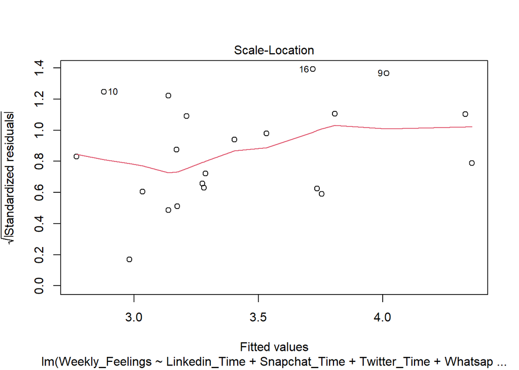

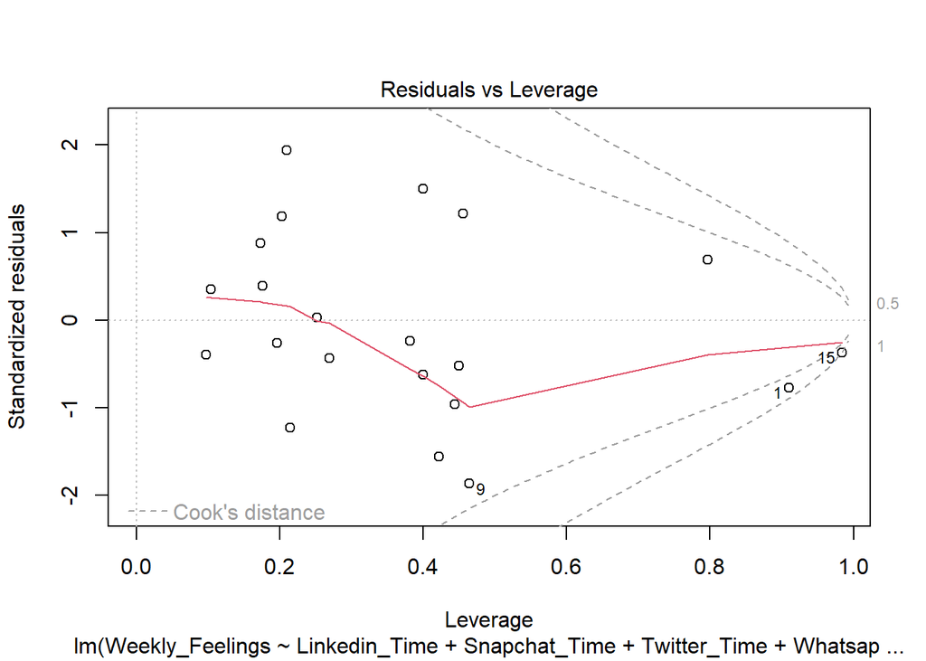

```r
plot(sm_model_fit)
```

```r
anova_result <- anova(sm_model_fit)
print(anova_result)
```

```
## Analysis of Variance Table
##
## Response: Weekly_Feelings
##               Df Sum Sq Mean Sq F value  Pr(>F)
## Linkedin_Time  1 1.9239 1.92394  3.4844 0.08466 .
## Snapchat_Time  1 1.2279 1.22786  2.2237 0.15976
## Twitter_Time   1 0.2058 0.20578  0.3727 0.55207
## Whatsapp_Time  1 0.3833 0.38332  0.6942 0.41978
## Youtube_Time   1 0.0425 0.04250  0.0770 0.78581
## OTT_Time       1 0.0042 0.00421  0.0076 0.93176
## Reddit_Time    1 0.1772 0.17719  0.3209 0.58071
## Residuals     13 7.1781 0.55216
## ---
## Signif. codes:  0 '***' 0.001 '**' 0.01 '*' 0.05 '.' 0.1 ' ' 1
```